# seaborn-tutorial-basico

```python
import seaborn as sns
import matplotlib.pyplot as plt
import numpy as np
import pandas as pd
```

```python
# Acessando dataset
tips = sns.load_dataset('tips')
```

O dataset "tips" é um dos vários conjuntos de dados pré-carregados na biblioteca seaborn, que fornece informações sobre as gorjetas deixadas em um restaurante.

A partir deste dataset, é possível inferir as seguintes informações:

**Total de gorjetas**: O dataset "tips" fornece informações sobre o valor total da gorjeta deixada por cada cliente.

**Taxa de gorjeta**: Além do valor total da gorjeta, também é possível obter a taxa de gorjeta em relação ao valor da conta.

**Características demográficas dos clientes**: O dataset "tips" também pode fornecer informações sobre as características demográficas dos clientes, como gênero e fumante/não fumante.

**Relação entre características demográficas e gorjetas**: É possível inferir a relação entre as características demográficas dos clientes e o valor da gorjeta deixada, por exemplo, se há uma tendência de que mulheres deixem gorjetas maiores ou se fumantes tendem a deixar gorjetas mais baixas.

**Tempo do dia e quantidade de gorjetas**: O dataset "tips" também pode fornecer informações sobre o horário em que as gorjetas foram deixadas, permitindo inferir a relação entre o horário do dia e a quantidade de gorjetas deixadas.

Em resumo, o dataset "tips" da biblioteca seaborn fornece informações valiosas sobre hábitos de gorjetas em um restaurante, que podem ser usadas para entender padrões e tendências entre os clientes.

```python
tips.head()
```

|  | total_bill | tip | sex | smoker | day | time | size |
| --- | --- | --- | --- | --- | --- | --- | --- |
| 0 | 16.99 | 1.01 | Female | No | Sun | Dinner | 2 |
| 1 | 10.34 | 1.66 | Male | No | Sun | Dinner | 3 |
| 2 | 21.01 | 3.50 | Male | No | Sun | Dinner | 3 |
| 3 | 23.68 | 3.31 | Male | No | Sun | Dinner | 2 |
| 4 | 24.59 | 3.61 | Female | No | Sun | Dinner | 4 |

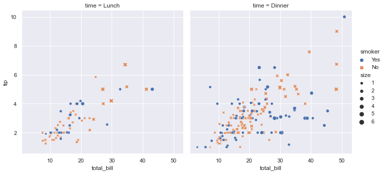

```python
# Visualizar os dados
sns.set_theme()
sns.relplot(data=tips, x = 'total_bill', y = 'tip', col= 'time', hue='smoker', style='smoker', size = 'size')
```

#### Explicação:

O gráfico seria construído usando o valor da conta total (total_bill) como o valor do eixo x e o valor da gorjeta (tip) como o valor do eixo y. O gráfico seria dividido em duas colunas, uma para o almoço (time) e outra para o jantar.

Em resumo, o gráfico resultante seria uma visualização bidimensional das relações entre as variáveis presentes no dataset "tips".

```python
# Outro dataset
iris = sns.load_dataset('iris')
iris.head()
```

|  | sepal_length | sepal_width | petal_length | petal_width | species |
| --- | --- | --- | --- | --- | --- |
| 0 | 5.1 | 3.5 | 1.4 | 0.2 | setosa |
| 1 | 4.9 | 3.0 | 1.4 | 0.2 | setosa |
| 2 | 4.7 | 3.2 | 1.3 | 0.2 | setosa |
| 3 | 4.6 | 3.1 | 1.5 | 0.2 | setosa |
| 4 | 5.0 | 3.6 | 1.4 | 0.2 | setosa |

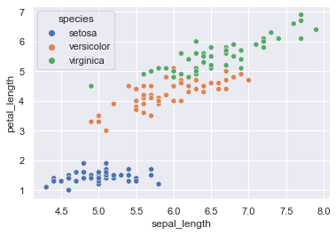

```python
sns.scatterplot(x='sepal_length', y='petal_length', hue='species', data=iris)
```

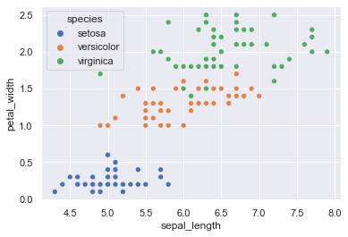

```python
sns.scatterplot(x='sepal_length', y='petal_width', hue='species', data=iris)
```

#### Explicação:

o gráfico de dispersão mostrará a relação entre a variável "sepal_length" (comprimento da sépala) e a variável "petal_width" (largura da pétala) no dataset iris.

O parâmetro "hue" é usado para especificar uma terceira variável categórica, "species" (espécie), que será usada para colorir os pontos no gráfico. Assim, cada espécie de iris será representada por uma cor diferente no gráfico, permitindo que você veja facilmente as relações entre o comprimento e a largura da sépala e da pétala para cada espécie.

O resultante do comando será um gráfico de dispersão onde cada ponto representa uma observação (amostra) no seu conjunto de dados iris. A posição de cada ponto no gráfico será determinada pelo valor de "sepal_length" no eixo x e pelo valor de "petal_width" no eixo y. E, a cor de cada ponto será determinada pela espécie a que a observação pertence.

Esse tipo de gráfico é útil para explorar as relações entre duas variáveis quantitativas, especialmente quando você tem uma terceira variável categórica que pode ser usada para colorir os pontos. Isso pode ajudar a identificar padrões e tendências nos dados que podem não ser óbvios a partir de uma simples tabela de valores.

```python
titanic = sns.load_dataset('titanic')
```

O dataset titanic contém informações como idade, classe socioeconômica, gênero e sobrevivência dos passageiros. Algumas das variáveis incluem:

**pclass**: a classe socioeconômica do passageiro, com valores 1, 2 ou 3.

**sex**: o gênero do passageiro, masculino ou feminino.

**age**: a idade do passageiro.

**fare**: o preço pago pelo bilhete.

**embarked**: o porto de embarque do passageiro, com valores "C" (Cherbourg), "Q" (Queenstown) ou "S" (Southampton).

Este dataset é amplamente usado como exemplo de estudos de aprendizado de máquina supervisionado, pois fornece uma série de variáveis que podem ser usadas para prever a sobrevivência dos passageiros.

Ao carregar o dataset titanic com este comando, ele é armazenado na variável "titanic". Depois disso, você pode usar as funções de visualização de dados da biblioteca seaborn para explorar e visualizar as informações contidas neste dataset.

```python
titanic.head()
```

|  | survived | pclass | sex | age | sibsp | parch | fare | embarked | class | who | adult_male | deck | embark_town | alive | alone |
| --- | --- | --- | --- | --- | --- | --- | --- | --- | --- | --- | --- | --- | --- | --- | --- |
| 0 | 0 | 3 | male | 22.0 | 1 | 0 | 7.2500 | S | Third | man | True | NaN | Southampton | no | False |
| 1 | 1 | 1 | female | 38.0 | 1 | 0 | 71.2833 | C | First | woman | False | C | Cherbourg | yes | False |
| 2 | 1 | 3 | female | 26.0 | 0 | 0 | 7.9250 | S | Third | woman | False | NaN | Southampton | yes | True |
| 3 | 1 | 1 | female | 35.0 | 1 | 0 | 53.1000 | S | First | woman | False | C | Southampton | yes | False |
| 4 | 0 | 3 | male | 35.0 | 0 | 0 | 8.0500 | S | Third | man | True | NaN | Southampton | no | True |

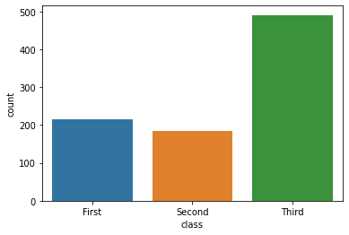

```python
sns.countplot(x='class', data=titanic)
```

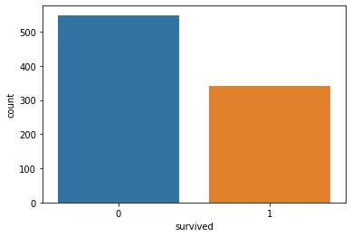

```python
sns.countplot(x='survived', data=titanic)
```

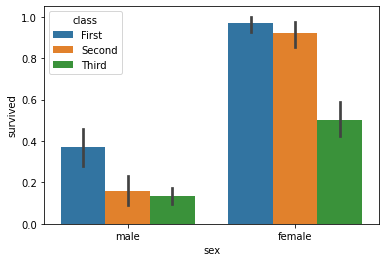

```python
sns.barplot(x='sex', y='survived', hue='class', data=titanic)
```